# Results from deterministic approach

Olalla Diaz Yañez

2/21/2018

These plots are the results from the deterministic approach.

The changes compared to the previous one are:

- LEV is actualize to the true year 0 (considering the age of the stand).
- Mortality due to competition is now estimated using the modified model that only consder whole alive trees and standing dead trees.

## Initial cost vs rotation length

Higher initial costs –> longer rotations

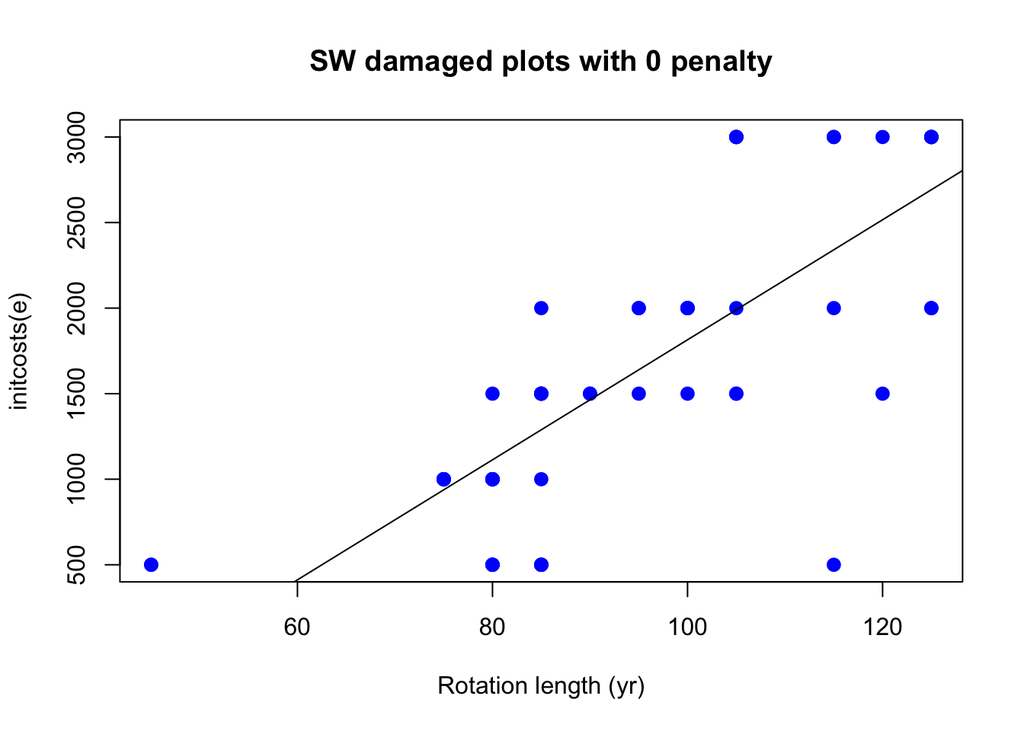

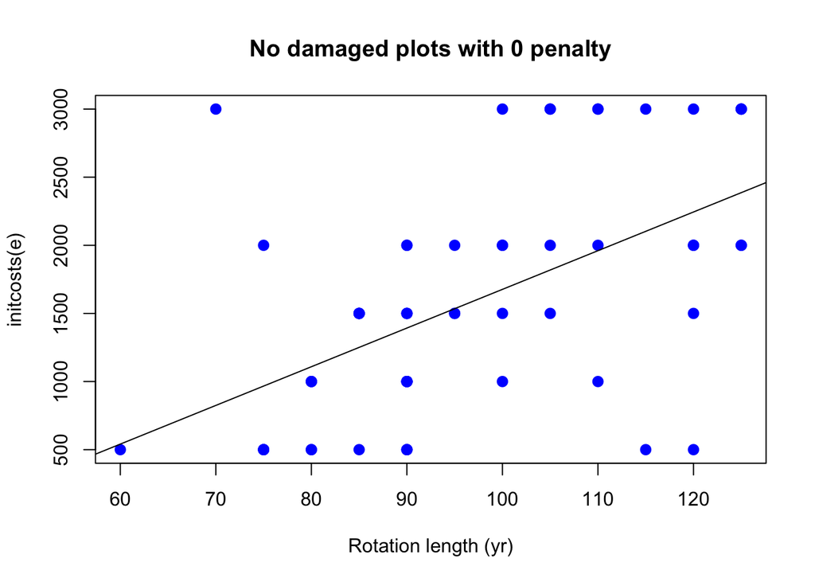

## Discount rate vs rotation length

Higher discount rates –> shorter rotation lengths

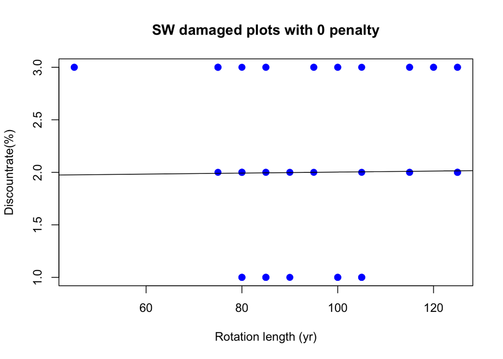

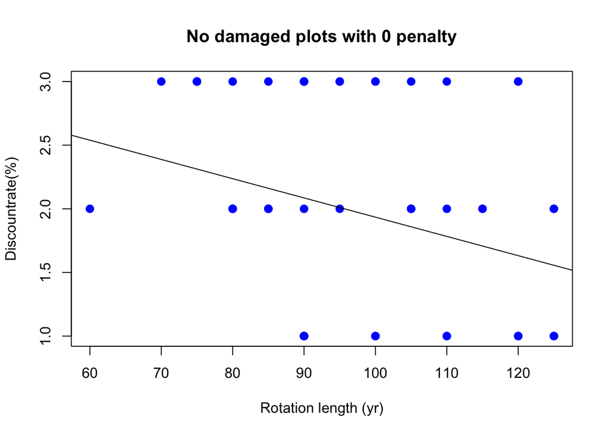

## Discount rate vs LEV final

Lower discount rates –> Higher final LEV

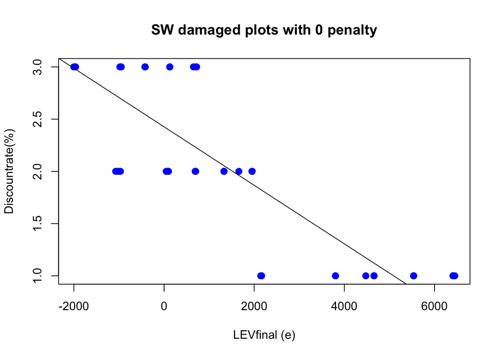

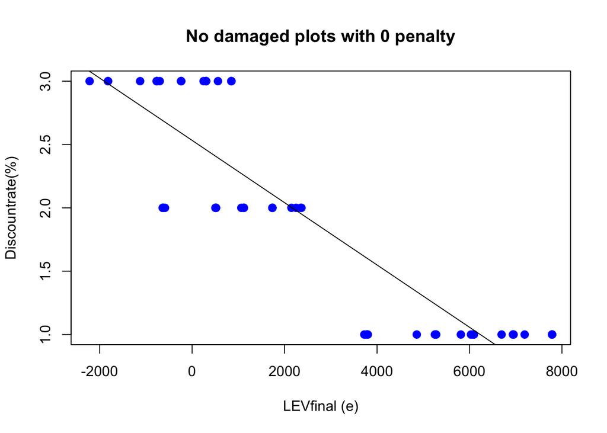

## Number of thinnings vs rotation length—-

Higher number of thinnings –> Longer rotation lengths

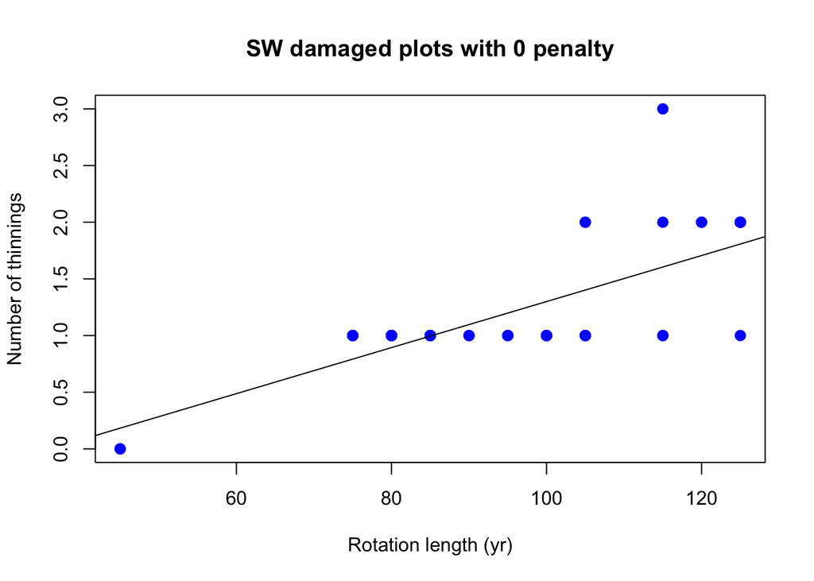

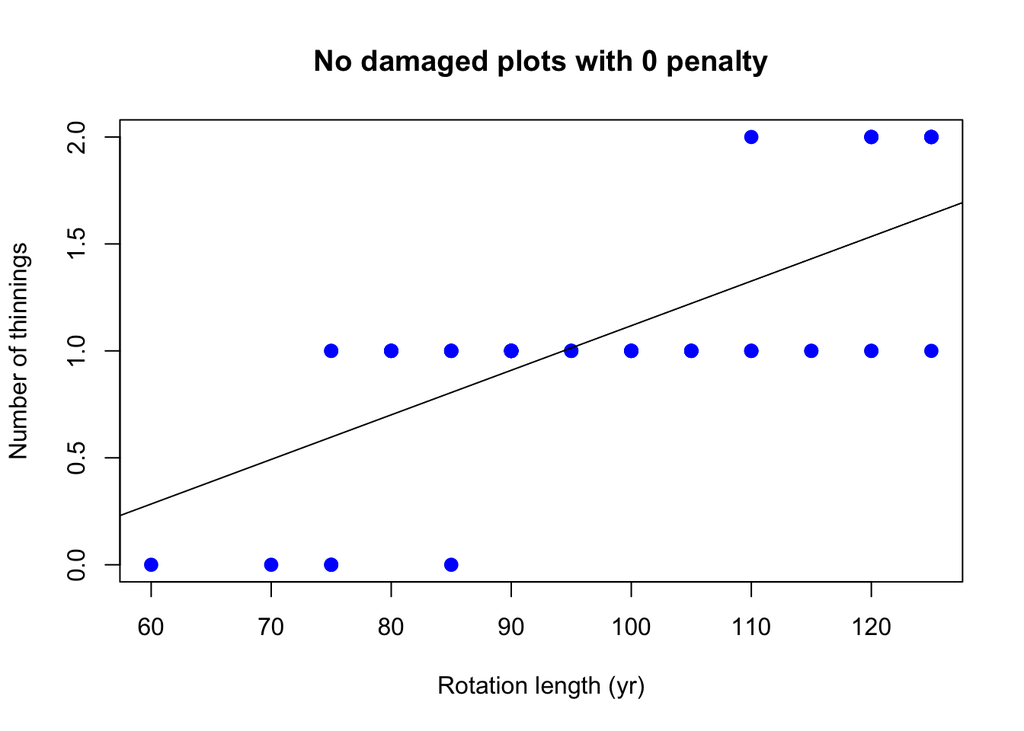

## Rotation length vs Final LEV

Damaged plots: Longer rotation lengths –> Lower final LEV Undamaged plots: Longer rotation lengths –> Higher final LEV

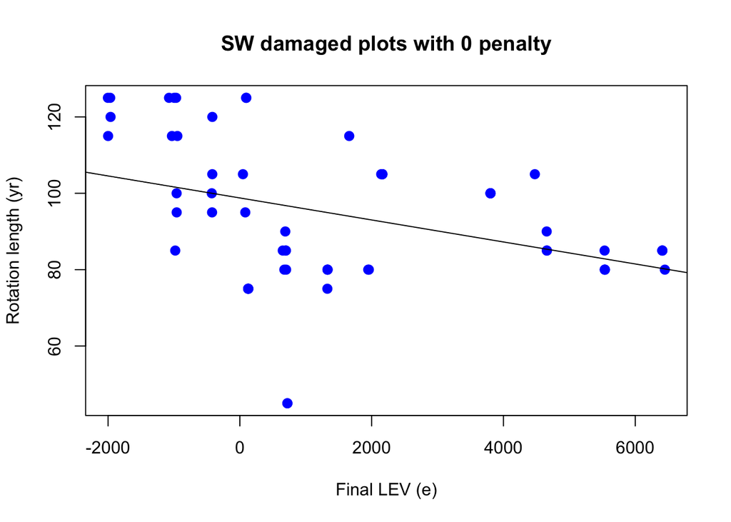

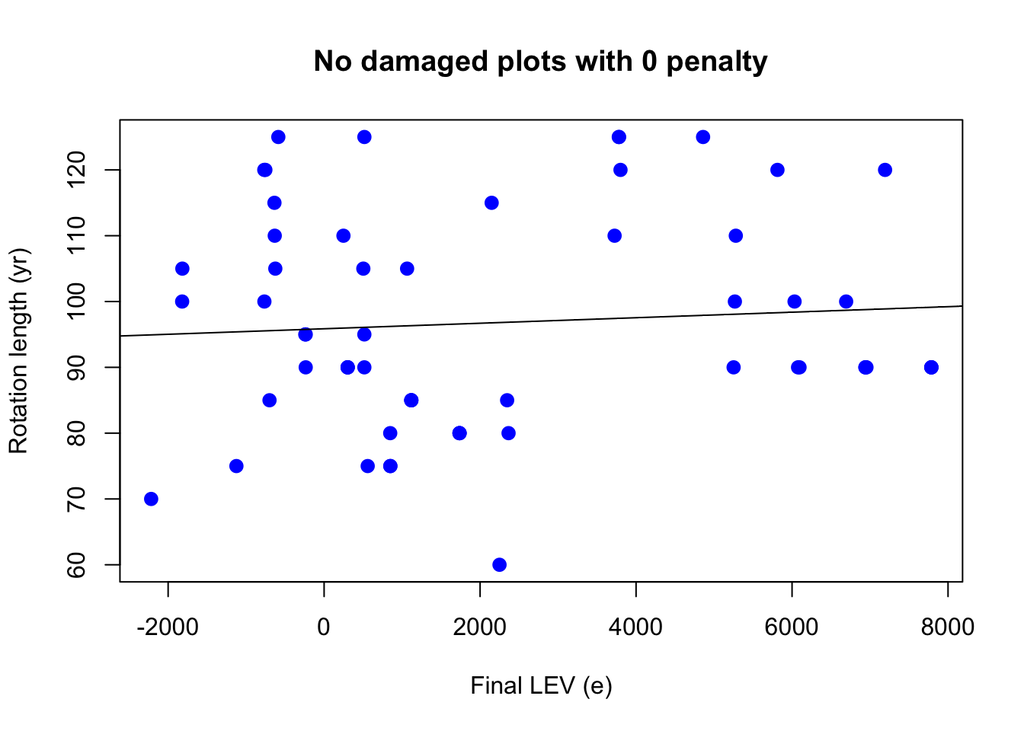

## Average carbon above ground per year vs rotations length

Higher carbon –> Longer rotation lengths

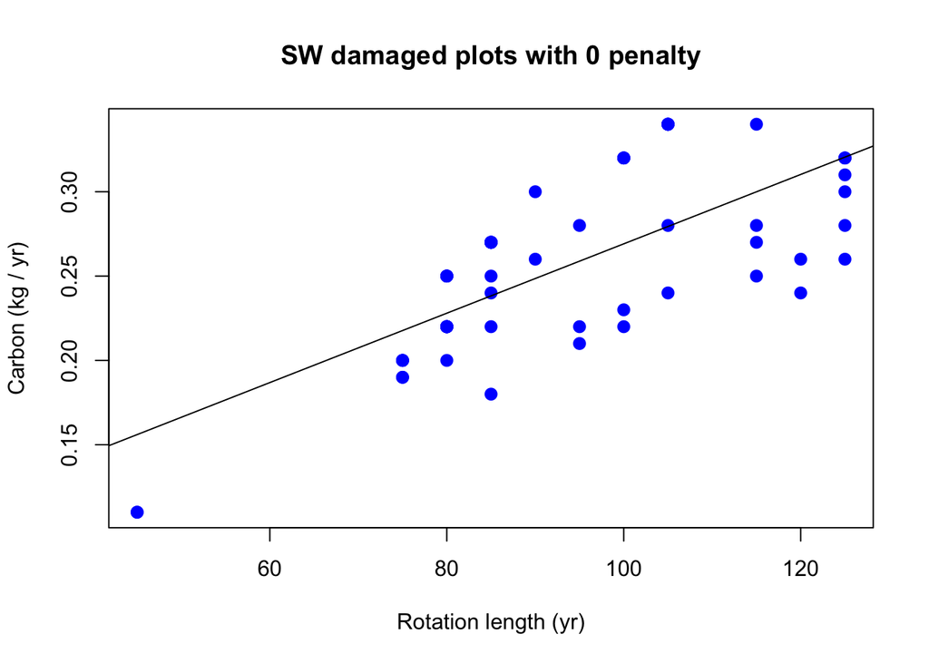

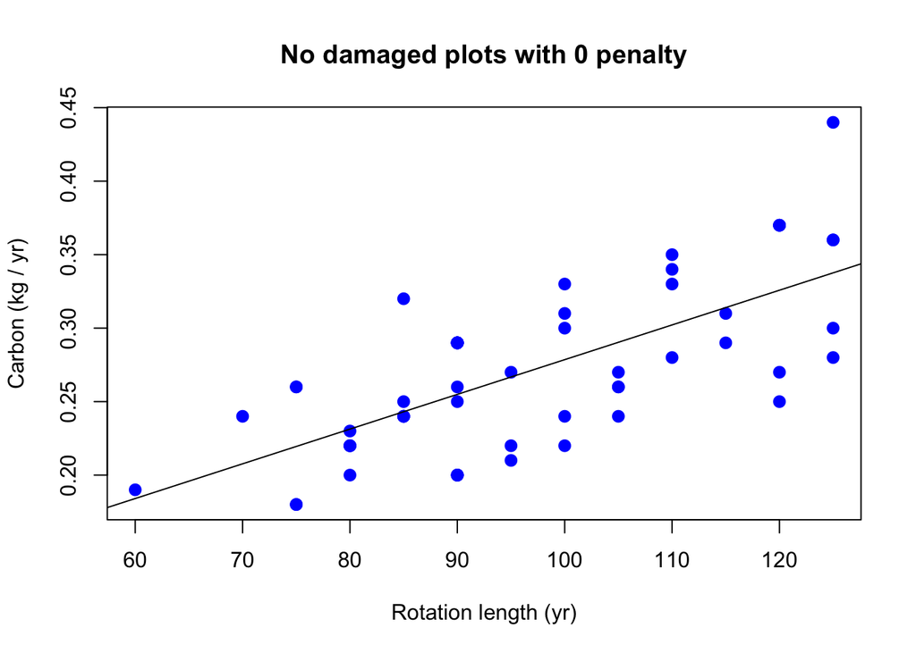

## Risk as average m3 of wood damage per year vs rotation length

Higher risk –> Longer rotation lengths

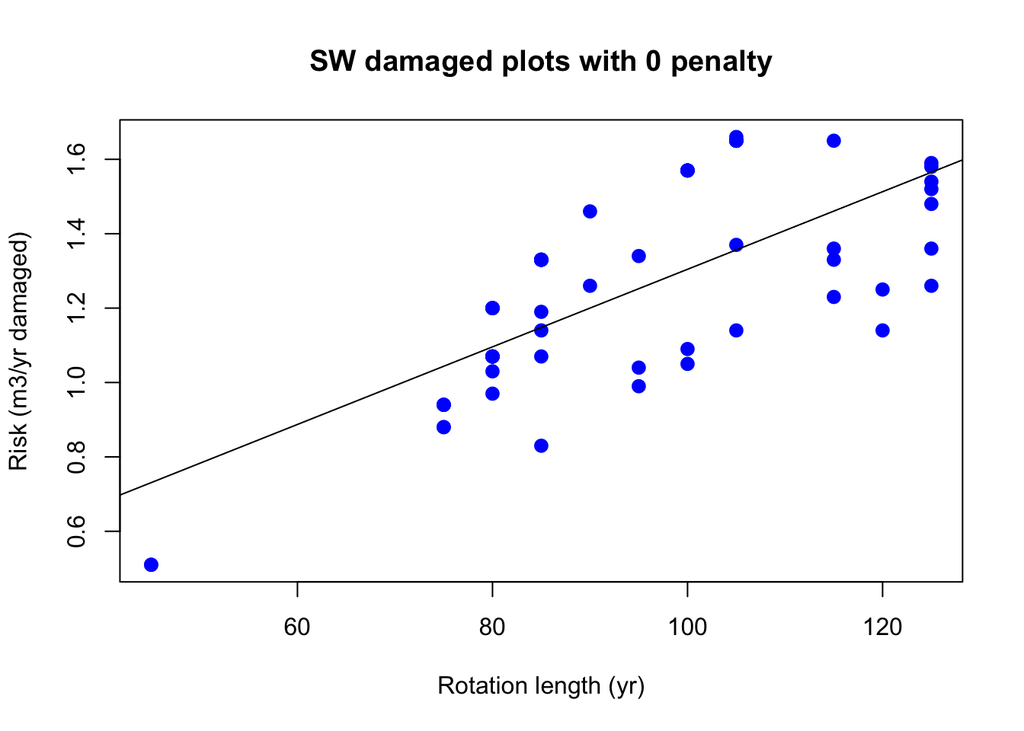

## Risk as average m3 of wood damage per year vs LEV final

Higer risk –> Higher LEV or not clear pattern?

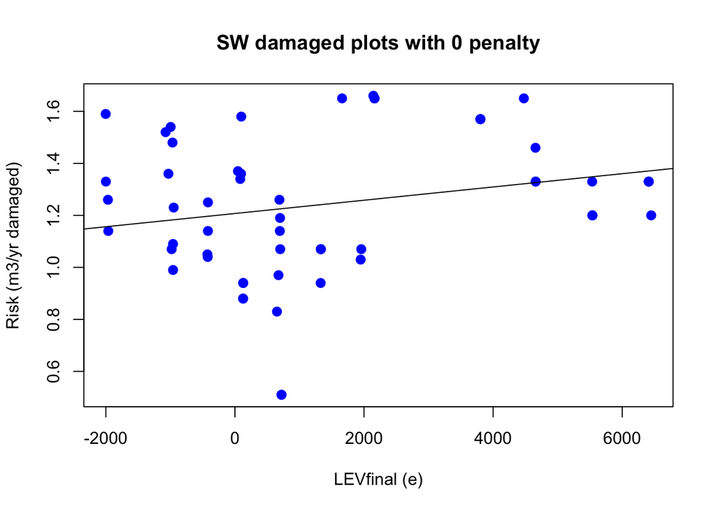

## Risk as average m3 of wood damage per year vs Biodiversity proxy (average of dead biomass per year)

Higer risk –> Higher biodiversity

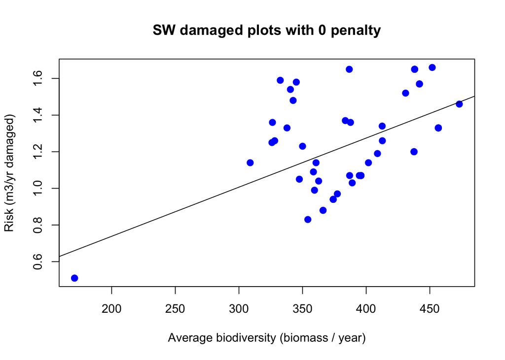

## Risk as average m3 of wood damage per year vs number of thinnings

Higer risk –> More thinnings

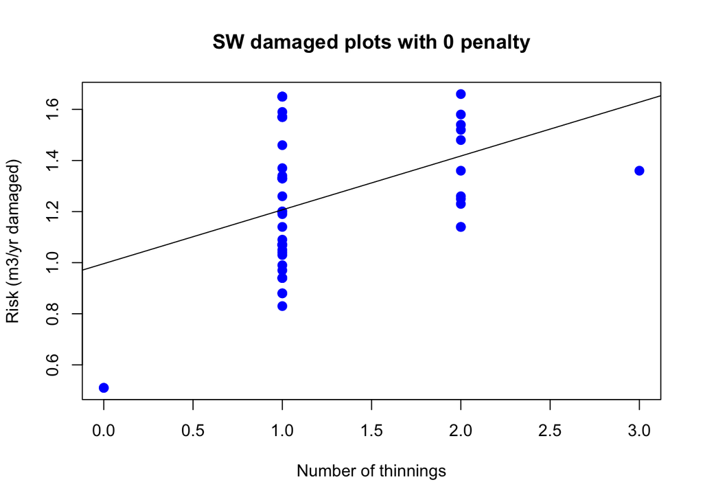